# tiktok_presentation slides

## How To Become Tiktok Famous 💃

- Tiktok is a short video sharing application with over 1.1 billion users, known for accelerating the transfer of internet cultures, trends and music.
- This will be an investigation into the various aspects of what it takes to become Tiktok Famous - music, video, creator demographics
- Data sourced from manually from Tiktok API, Kaggle data using Tiktok and Spotify APIs

### Do I have what it takes to become famous?

[figure not shown]

## What Music Should I Pick? 🎶

The sound paired with a Tiktok is a huge factor to it's success. Let's look into what makes a sound popular.

```
Index(['track_name', 'artist_name', 'artist_pop', 'album', 'track_pop',
       'danceability', 'energy', 'loudness', 'mode', 'key', 'speechiness',
       'acousticness', 'instrumentalness', 'liveness', 'valence', 'tempo',
       'time_signature', 'duration_ms'],
      dtype='object')
```

## Which artist should I pick? 🎤

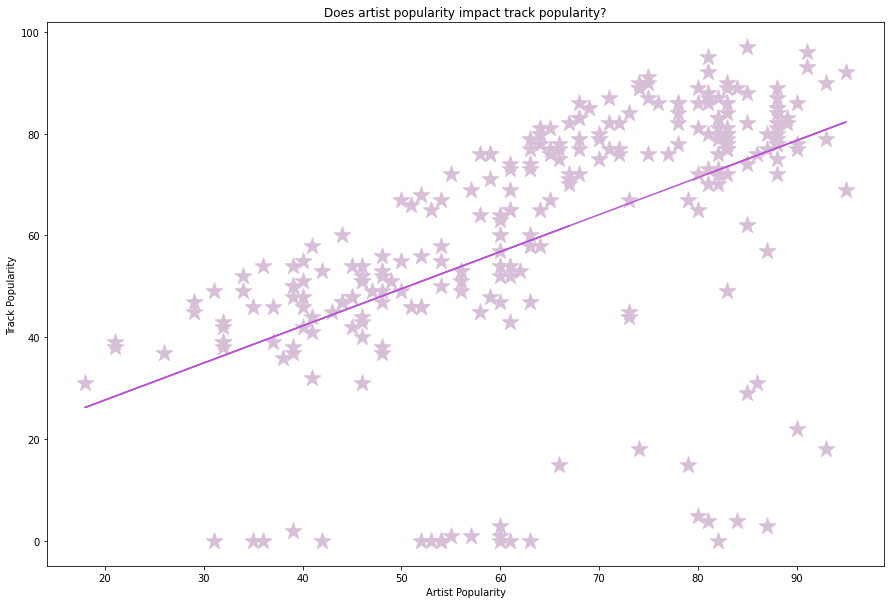

- We notice that there is a direct positive correlation between artist and track popularity
- This indicates how viewers are likely to connect with popular artists they already know and hence tracks from these artists will perform better
- For examples, songs by The Weekend, Drake and Harry Styles performed really strongly

## What goes into a popular hit track 🎵

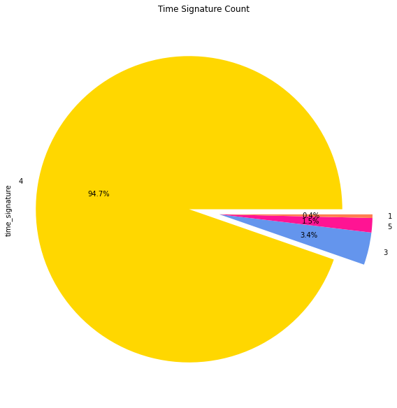

- A majority of the songs here are in quadruple time
- Quadruple time is commonly used in Western pop music - it's familiar and makes the music more accessible and easy to connect to
- The steady and relatively predicable pattern makes allows people to easily choreograph and dance to the music.

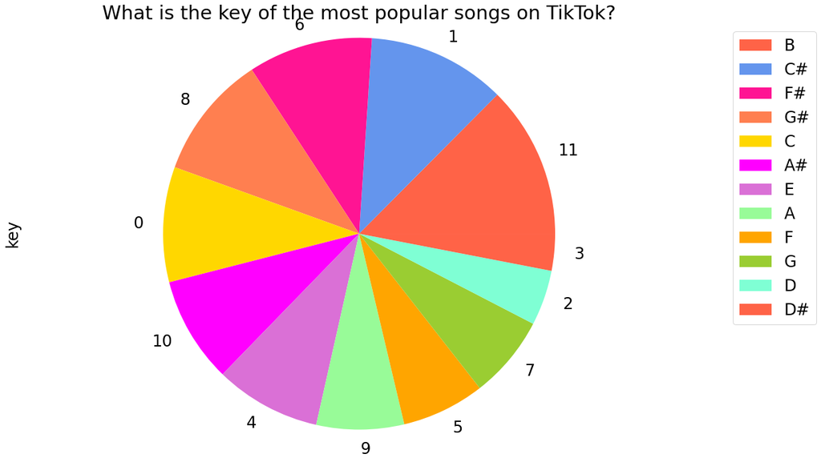

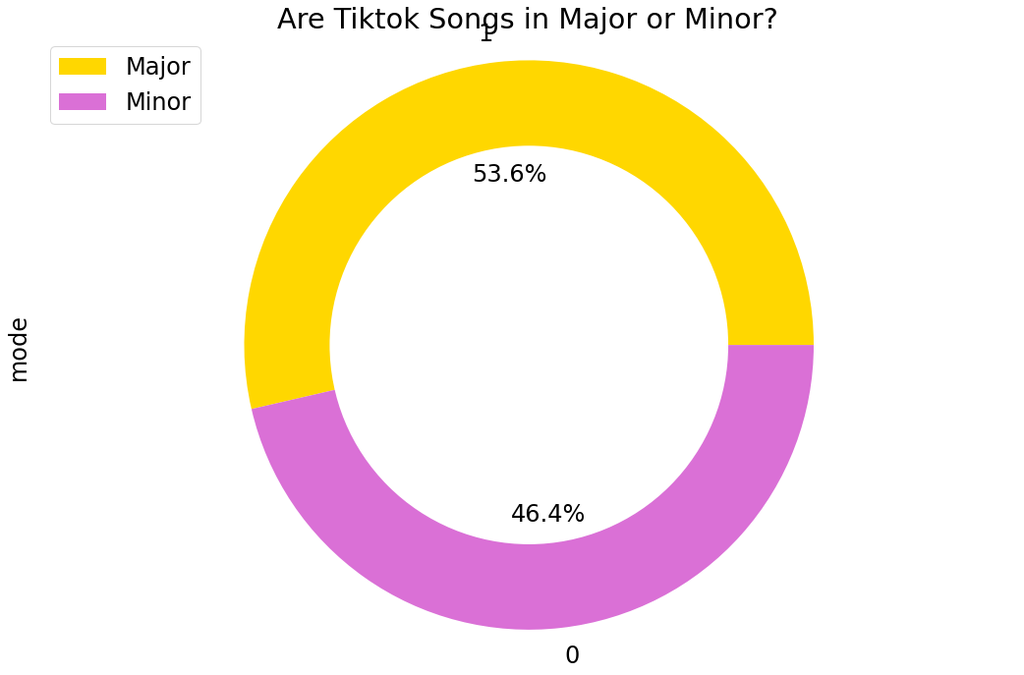

## Look into the top 250 Most Followed 👥

```
done
```

|  | Rank | Username | Country | Followers | Views | Likes | Engagement | Brand Account | Gender | Age | Ethnicity | Famous | Genre | LGBTQ |
| --- | --- | --- | --- | --- | --- | --- | --- | --- | --- | --- | --- | --- | --- | --- |
| 0 | 1 | @charlidamelio | U.S.A | 78.9m | 38.3m | 6.1m | 16.60% | 0 | Female | 16.0 | White | 0.0 | Dancing, Lipsyncing, Lifestyle | 0.0 |
| 1 | 2 | @addisonre | U.S.A | 53.7m | 13.8m | 2.8m | 20.80% | 0 | Female | 19.0 | White | 0.0 | Dancing, Lipsyncing | 0.0 |
| 2 | 3 | @zachking | U.S.A | 47.3m | 17.6m | 2.8m | 16% | 0 | Male | 30.0 | East Asian | 1.0 | Comedy, Illusion | 0.0 |
| 3 | 4 | @lorengray | U.S.A | 46.3m | 3.2m | 622.6k | 19.70% | 0 | Female | 18.0 | White | 1.0 | Dancing, Lipsyncing | 0.0 |
| 4 | 5 | @tiktok | U.S.A | 45.3m | 9.4m | 503.0k | 5.60% | 1 | NaN | NaN | NaN | 1.0 | NaN | NaN |

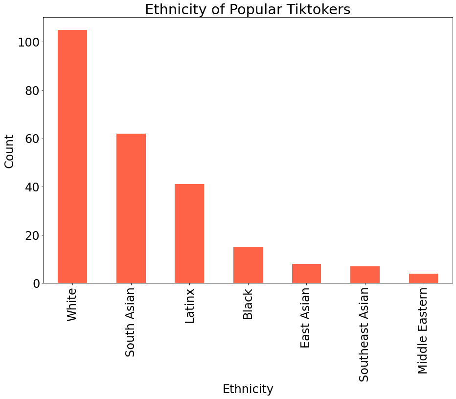

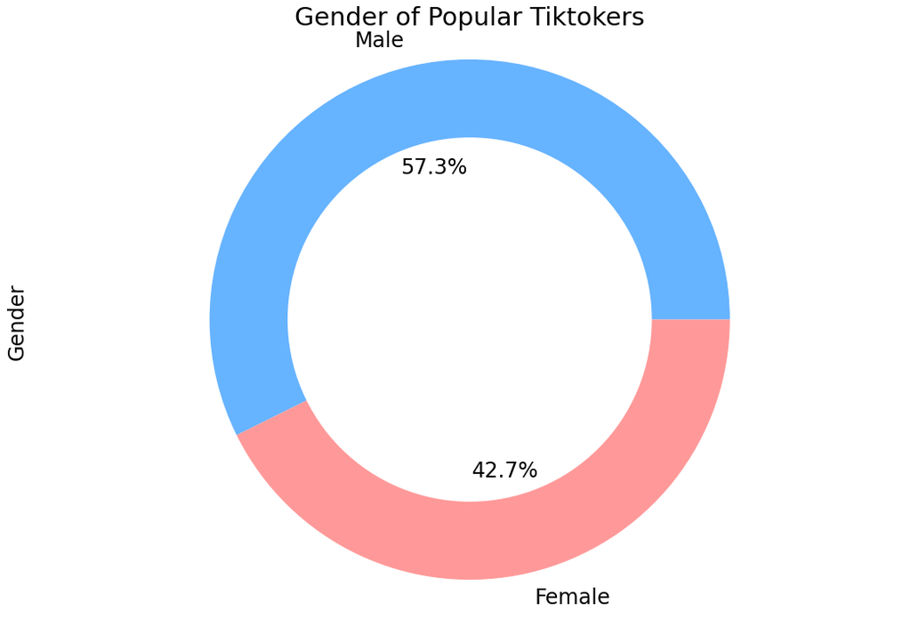

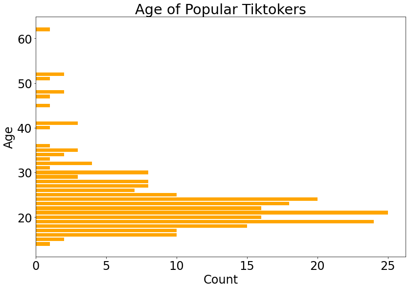

```
Average age of popular tiktokers:  23.817777777777778
Median age of popular tiktokers:  22.0
```

- The most followed Tiktokers are clustered in the early 20s age range as shown in the graph
- This reflects the popularity of Tiktok as a social media platform with young people
- The average age of popular tiktoker is a bit older than the highest density age demographic 10-19 as it portrays an aspirational representation of where they may be in a few year - role models

## What are the topics and genres that are popular? 😂

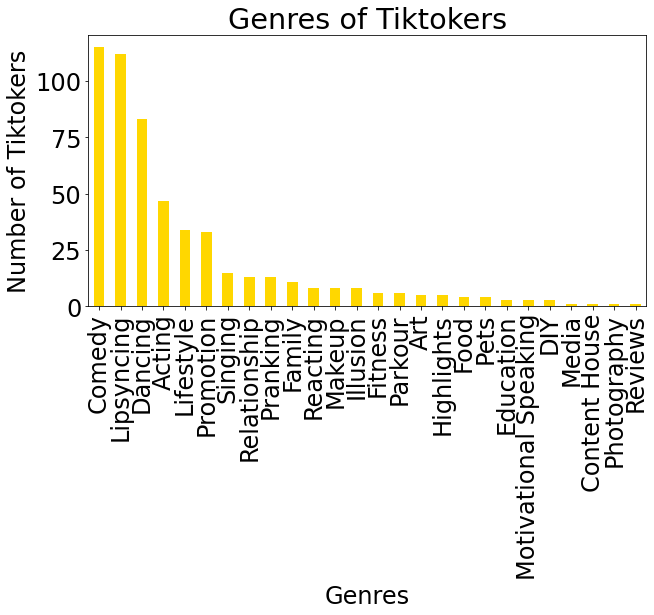

- Genres which are popular are more accessible and have a lower barrier to entry tend to have a larger audience
- Take for example Comdedy and Lipsyncing compared to more speciality topics like Art and Fitness which requires special equipment, knowledge and appreciation

## Where are popular Tiktokers from? 🌏

- We notice countries with a well established entertainment scheme represent
- United States, India, Brazil, South Korea are countries with well established entertainment industries
- Mexico because of it's proximity to U.S.A and the cultural influences.
- Australia's cultural influence from American popular culture.

[figure not shown]

## What's on my FYP ✨

- Fyp is an acronym that means “For You Page”, and refers to the page on TikTok that is filled with recommended content and videos the app thinks you'll enjoy the most.
- Using an API wrapper I was able to extract data from my Tiktok account and scrap the metadata of 500 videos on my FYP

|  | author_nickname | author_signature | author_uniqueId | author_verified | authorStats_diggCount | authorStats_followerCount | authorStats_followingCount | authorStats_heart | authorStats_heartCount | authorStats_videoCount | ... | Unnamed: 54 | Unnamed: 55 | Unnamed: 56 | Unnamed: 57 | Unnamed: 58 | Unnamed: 59 | Unnamed: 60 | Unnamed: 61 | Unnamed: 62 | Unnamed: 63 |
| --- | --- | --- | --- | --- | --- | --- | --- | --- | --- | --- | --- | --- | --- | --- | --- | --- | --- | --- | --- | --- | --- |
| 0 | Snake movie 54 | Thank you for following along | lkmouhxrd6f | False | 9 | 489500 | 12.0 | 19400000 | 19400000 | 142 | ... | NaN | NaN | NaN | NaN | NaN | NaN | NaN | NaN | NaN | NaN |
| 1 | Luke | 🦥\nFooty and cricket>>>\nFreo💜🤍\nFlagmantle 23... | _flagmantle | False | 395 | 1261 | 39.0 | 56700 | 56700 | 64 | ... | NaN | NaN | NaN | NaN | NaN | NaN | NaN | NaN | NaN | NaN |
| 2 | cirqnamics | World Renowned 7thGen Circus Family | cirqnamics | False | 893 | 632700 | 977.0 | 17800000 | 17800000 | 289 | ... | NaN | NaN | NaN | NaN | NaN | NaN | NaN | NaN | NaN | NaN |
| 3 | Bailey | a girl of many talents \nmy worst enemy out no... | baileyspinn | True | 354200 | 14600000 | 1800.0 | 656000000 | 656000000 | 2334 | ... | NaN | NaN | NaN | NaN | NaN | NaN | NaN | NaN | NaN | NaN |
| 4 | Twins Style | 🇵🇱 Poland📍\nHubert & Sebastian\n📩 twinsstyle@m... | twinsstylee | True | 33100 | 18500000 | 127.0 | 405900000 | 405900000 | 1101 | ... | NaN | NaN | NaN | NaN | NaN | NaN | NaN | NaN | NaN | NaN |

5 rows × 64 columns

## What goes into a juicy description ✍🏻

- We notice a trend of the emojis commonly used in description being ones that have facial expressions such as crying laughing with tears and smiling emoji
- Facial emojis elicit emotions in the reader and are easy to relate to
- Emojis compensate quite effectively for the lack of non-verbal clues
- This mimics the trend we saw with the popular genres - comedy and lipsyncing were the most universal

[figure not shown]

- TikTok hashtags spread user-generated content to more users, helping them easily find & share the content they are interested in.
- We notice popular tiktoks use these hashtags - there are most commonly searched and known by other users and help propel the traction of the video
- Hashtags that do well are usually short words related to the app

[figure not shown]

- With Personal bio descriptions we see there is a common trend of emojis with a call to action such as an envelope and a down pointing arrow/finger
- These invite other users to message the user which creates new touchpoints and conversations
- Creates a sense of sincerity and attainability
- Down pointer prompts other users to view a link which may be an Instagram account, blog or online shop
- Tiktok influences often have an extension of their personal brand through the link, and it makes them seem more genuine and real.

[figure not shown]

## Should I have numbers in my name and username 🔢

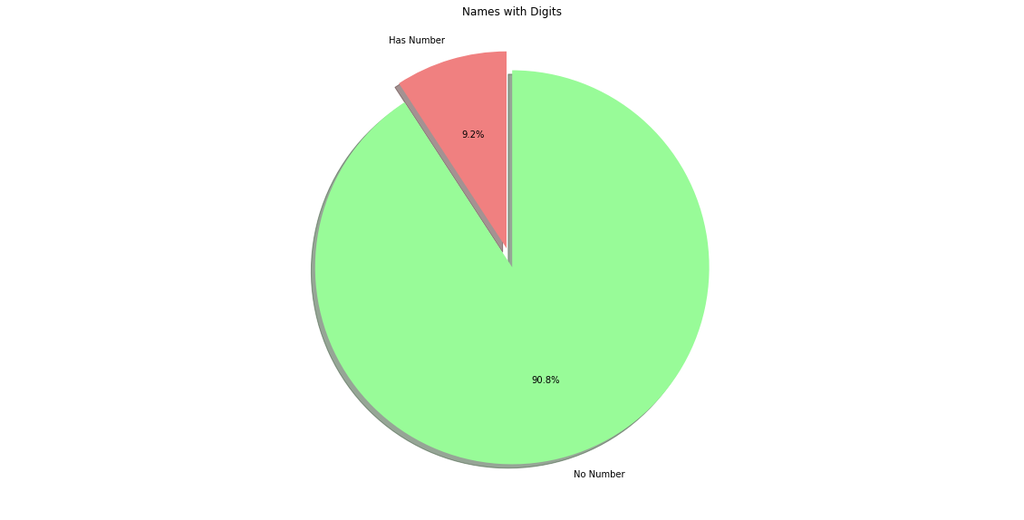

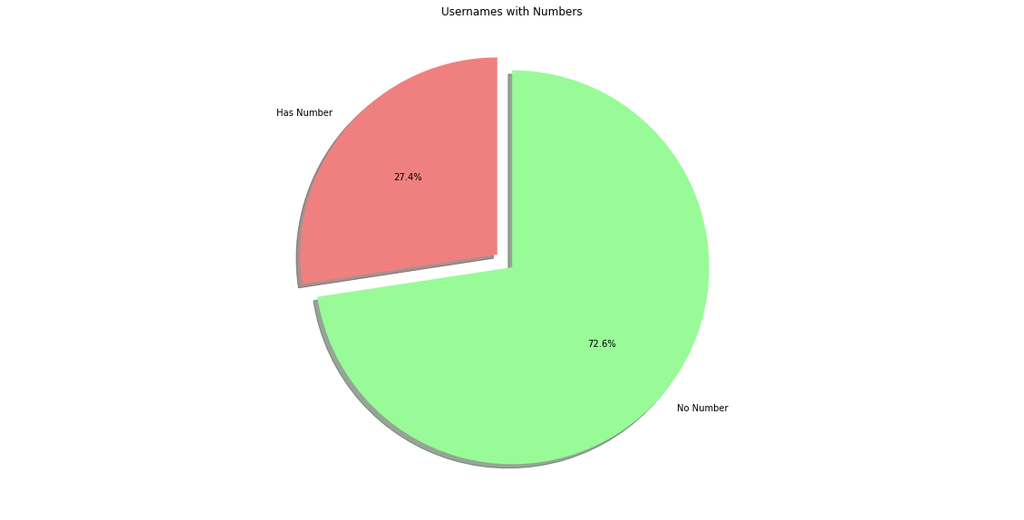

### Avoid numbers in name and username

- When we were young I'm sure we've have usernames like mangogirl12345 with a bunch of numbers
- But we've noticed that this is not optimal for tiktok fame
- Viewers are less likely to remeber sequences of numbers that accompany a username or name
- We notice a majority of the top performing videos come from tiktokers without numbers in their names and usernames

## How long are popular Tiktoks? ⌛

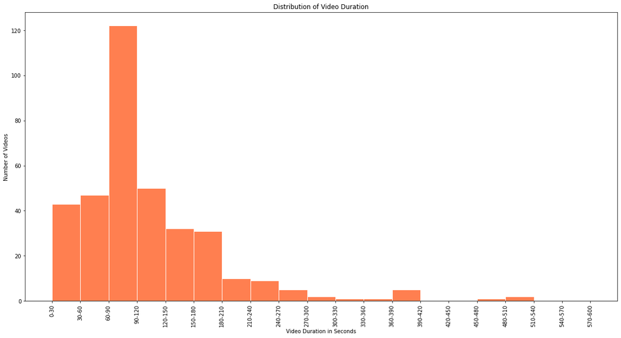

- We know that Tiktok is a short video sharing platform, but what is the length of an optimal video to both engage but not bore.
- From the video times, I grouped the data into 30 second intervals and investigated the duration of videos on my FYP.
- A noticeable proportion of videos are in the 60 - 90 second division
- Long enough to have substance but short enough to keep your attention span fresh

## When are popular videos posted 🕒

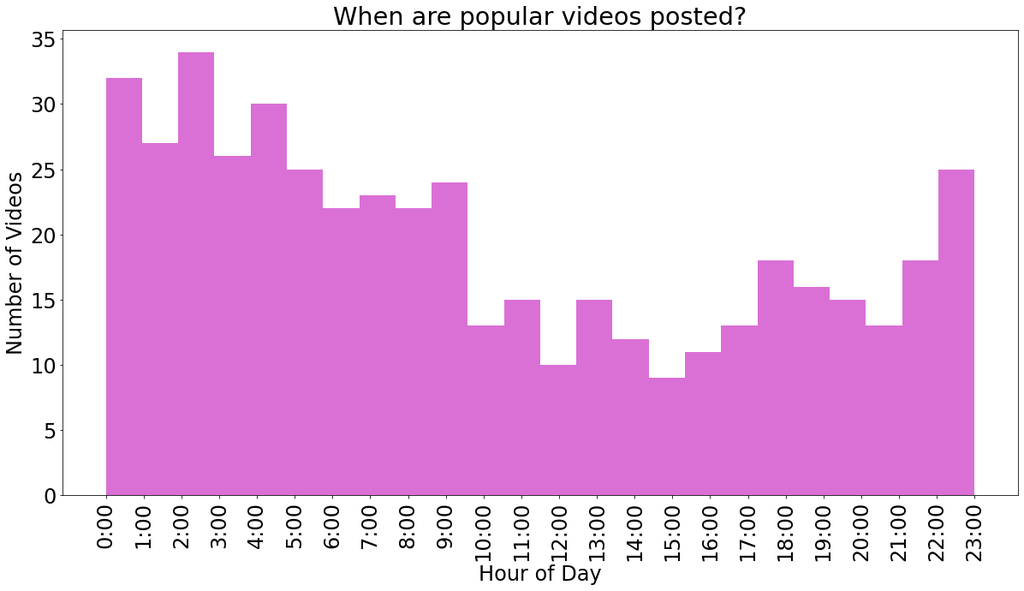

- Videos are posted in the hours of high online activity
- People tend to post before bed or in the early morning
- We notice a dip during the working and school day - There are less people using the app and less creators uploading during the time

## Summary 🍃

- Keep your content accessible and universal
- Choose music from popular music in a danceable beat
- Use engaging face emojis that resemble the human face and which have a call to action
- Keep videos under 2 minutes and post in the early morning
- Have a simple and easy to remember username

## Thank you for listening ❤️

- After all that, social media should be a place where you express yourself and your individuality
- Popularity and the numbers are transient, but the experience and memories stay with you